# Human Activity Recognition

Miguel Goncalves

## Synopsis

> Using devices such as Jawbone Up, Nike FuelBand, and Fitbit it is now possible to collect a large amount of data about personal activity relatively inexpensively. These type of devices are part of the quantified self movement - a group of enthusiasts who take measurements about themselves regularly to improve their health, to find patterns in their behavior, or because they are tech geeks. One thing that people regularly do is quantify how much of a particular activity they do, but they rarely quantify how well they do it. In this project, or objective is to develop a model that correclty predicts the way that the activities are performed by using data from accelerometers on the belt, forearm, arm, and dumbell of 6 participants. They were asked to perform barbell lifts correctly and incorrectly in 5 different ways. More information is available from the [Human Activity Recognition](http://groupware.les.inf.puc-rio.br/har) (see the section on the Weight Lifting Exercise Dataset) website

### Data Processing

The data used can be found here:

- [Train Set](https://d396qusza40orc.cloudfront.net/predmachlearn/pml-training.csv)
- [Test Set](https://d396qusza40orc.cloudfront.net/predmachlearn/pml-testing.csv)

The dataset presents markers that indicate the end of a window of observation, given that the test set we are going to evaluate or predictions on doesn’t have any of this “end of window” markets, we will remove them from the analysis. Also, this markers indicate observation where summary statistics of the activity performed in the corrresponding window are reported , therefore many of the variables will turn NAs on all of their existance one this markers are removed. These wariables are also removed.

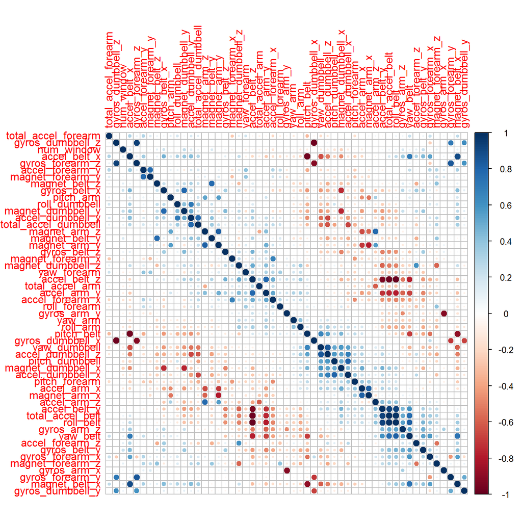

### Subsetting

The dataset is sliced into a TRAINING set, covering 70% of the data, and a TEST set, with the remaining 30%, by random sampeling.

```r
set.seed(3108)
train_sample <- createDataPartition(y=reduced_data_set$classe, p=0.7, list = F)
training <- reduced_data_set[train_sample,]
testing <- reduced_data_set[-train_sample,]
trainingSize<-dim(training)
testingSize <-dim(testing)
predictors <- names(training)[8:testingSize[2]]
training <- training[,predictors]
testing  <- testing[,predictors]
predictors <- names(reduced_predict_20)[8:testingSize[2]]
prediction <- reduced_predict_20[,predictors]
```

The TRAINING set has 13453 observations while the TEST set has 5763

### Modeling

We start with a **Desicion Tree** with a complexity parameter *cp=0.01* and cross-validation using random sapeling *Bootstrap*:

```
## CART
##
## 13453 samples
##    52 predictor
##     5 classes: 'A', 'B', 'C', 'D', 'E'
##
## No pre-processing
## Resampling: Bootstrapped (25 reps)
## Summary of sample sizes: 13453, 13453, 13453, 13453, 13453, 13453, ...
## Resampling results
##
##   Accuracy   Kappa      Accuracy SD  Kappa SD
##   0.7273871  0.6537087  0.02168525   0.02714199
##
## Tuning parameter 'cp' was held constant at a value of 0.01
##
```

The estimated model shows **Accuracy**=0.7273871 and **Kappa**=0.6537087

```
## Confusion Matrix and Statistics
##
##           Reference
## Prediction    A    B    C    D    E
##          A 1480   55   40   29   37
##          B  183  626  203   75   28
##          C   25   48  861   68    3
##          D   58   63   82  660   81
##          E   12   79  131   75  761
##
## Overall Statistics
##
##                Accuracy : 0.7614
##                  95% CI : (0.7502, 0.7724)
##     No Information Rate : 0.305
##     P-Value [Acc > NIR] : < 2.2e-16
##
##                   Kappa : 0.6977
##  Mcnemar's Test P-Value : < 2.2e-16
##
## Statistics by Class:
##
##                      Class: A Class: B Class: C Class: D Class: E
## Sensitivity            0.8419   0.7187   0.6538   0.7277   0.8363
## Specificity            0.9598   0.9000   0.9676   0.9415   0.9388
## Pos Pred Value         0.9019   0.5614   0.8567   0.6992   0.7193
## Neg Pred Value         0.9326   0.9473   0.9042   0.9487   0.9683
## Prevalence             0.3050   0.1511   0.2285   0.1574   0.1579
## Detection Rate         0.2568   0.1086   0.1494   0.1145   0.1320
## Detection Prevalence   0.2847   0.1935   0.1744   0.1638   0.1836
## Balanced Accuracy      0.9008   0.8094   0.8107   0.8346   0.8875
```

The out of sample evaluation show an **Accuracy**=0.761409 and **Kappa**=0.6977089

We plot the estimated desicion tree

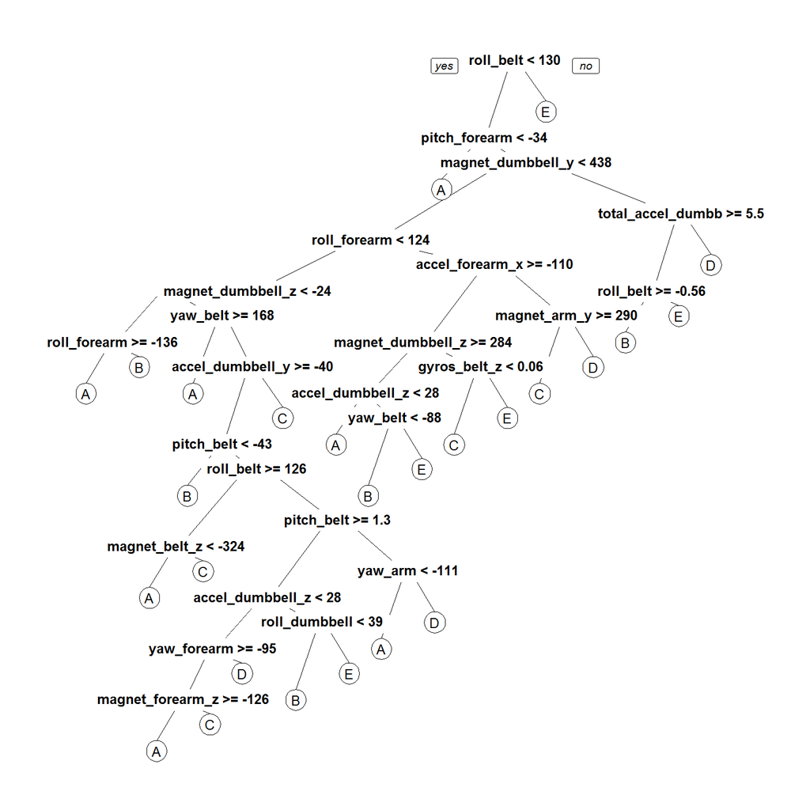

The desicion tree model has a relatively low performance in the context of our analysis, therefore we will estimate a Random Forest looking for better accuracy.

```
## Random Forest
##
## 13453 samples
##    52 predictor
##     5 classes: 'A', 'B', 'C', 'D', 'E'
##
## No pre-processing
## Resampling: Bootstrapped (25 reps)
## Summary of sample sizes: 13453, 13453, 13453, 13453, 13453, 13453, ...
## Resampling results across tuning parameters:
##
##   mtry  Accuracy   Kappa      Accuracy SD  Kappa SD
##    2    0.9876776  0.9844006  0.001946220  0.002464941
##   27    0.9883519  0.9852557  0.001495137  0.001892263
##   52    0.9782496  0.9724686  0.004328571  0.005477711
##
## Accuracy was used to select the optimal model using  the largest value.
## The final value used for the model was mtry = 27.
```

The estimated random forest model shows **Accuracy**=0.9883519 and **Kappa**=0.9852557

The Random Forest model has far better in-sample accuracy than the Desicion Tree. Following, we evalute the out-of-sample performance:

```
## Confusion Matrix and Statistics
##
##           Reference
## Prediction    A    B    C    D    E
##          A 1638    2    0    0    1
##          B    4 1111    0    0    0
##          C    0    1 1004    0    0
##          D    0    0    3  941    0
##          E    0    0    1    0 1057
##
## Overall Statistics
##
##                Accuracy : 0.9979
##                  95% CI : (0.9964, 0.9989)
##     No Information Rate : 0.2849
##     P-Value [Acc > NIR] : < 2.2e-16
##
##                   Kappa : 0.9974
##  Mcnemar's Test P-Value : NA
##
## Statistics by Class:
##
##                      Class: A Class: B Class: C Class: D Class: E
## Sensitivity            0.9976   0.9973   0.9960   1.0000   0.9991
## Specificity            0.9993   0.9991   0.9998   0.9994   0.9998
## Pos Pred Value         0.9982   0.9964   0.9990   0.9968   0.9991
## Neg Pred Value         0.9990   0.9994   0.9992   1.0000   0.9998
## Prevalence             0.2849   0.1933   0.1749   0.1633   0.1836
## Detection Rate         0.2842   0.1928   0.1742   0.1633   0.1834
## Detection Prevalence   0.2847   0.1935   0.1744   0.1638   0.1836
## Balanced Accuracy      0.9984   0.9982   0.9979   0.9997   0.9994
```

The out of sample evaluation show an **Accuracy**=0.9979178 and **Kappa**=0.997366

Given the performance of the Random Forest we chose to make the prediction with this more accurate model.

### Prediction

We then predict the values using the test set of 20 observations:

```r
result <- predict(HARmodRF, prediction)
result
```

```
##  [1] B A B A A E D B A A B C B A E E A B B B
## Levels: A B C D E
```